# Intelligent Agents: Reflex-Based Agents for the Vacuum-cleaner World

Student Name: Ethan Chou

I have used the following AI tools: google Gemini

I understand that my submission needs to be my own work: EC

## Instructions

Total Points: Undergrads 100 + 5 bonus / Graduate students 110

Complete this notebook. Use the provided notebook cells and insert additional code and markdown cells as needed. Submit the completely rendered notebook as a HTML file.

In Visual Studio Code: Use Export (click on ... in the menu bar) to save your notebook as a HTML file.

In Colab you need to save the notebook on GoogleDrive and then add the following block

```python
!pip install nbconvert

from google.colab import drive
drive.mount('/content/drive')
!jupyter nbconvert --to html /content/drive/MyDrive/Colab\ Notebooks/Copy\ of\ robot_vacuum.ipynb
```

You will need to fix the file location on your GoogleDrive.

## Introduction

In this assignment you will implement a simulator environment for an automatic vacuum cleaner robot, a set of different reflex-based agent programs, and perform a comparison study for cleaning a single room. Focus on the **cleaning phase** which starts when the robot is activated and ends when the last dirty square in the room has been cleaned. Someone else will take care of the agent program needed to navigate back to the charging station after the room is clean.

## PEAS description of the cleaning phase

**Performance Measure:** Each action costs 1 energy unit. The performance is measured as the sum of the energy units used to clean the whole room.

**Environment:** A room with $n \times n$ squares where $n = 5$. Dirt is randomly placed on each square with probability $p = 0.2$. For simplicity, you can assume that the agent knows the size and the layout of the room (i.e., it knows $n$). To start, the agent is placed on a random square.

**Actuators:** The agent can clean the current square (action `suck`) or move to an adjacent square by going `north`, `east`, `south`, or `west`.

**Sensors:** Four bumper sensors, one for north, east, south, and west; a dirt sensor reporting dirt in the current square.

## The agent program for a simple randomized agent

The agent program is a function that gets sensor information (the current percepts) as the arguments. The arguments are:

- A dictionary with boolean entries for the for bumper sensors `north`, `east`, `west`, `south`. E.g., if the agent is on the north-west corner, `bumpers` will be `{"north" : True, "east" : False, "south" : False, "west" : True}`.
- The dirt sensor produces a boolean.

The agent returns the chosen action as a string.

Here is an example implementation for the agent program of a simple randomized agent:

```python
# make sure numpy is installed
!pip install -q numpy
```

```python
import numpy as np

actions = ["north", "east", "west", "south", "suck"]

def simple_randomized_agent(bumpers, dirty):
    return np.random.choice(actions)
```

```python
# define percepts (current location is NW corner and it is dirty)
bumpers = {"north" : True, "east" : False, "south" : False, "west" : True}
dirty = True

# call agent program function with percepts and it returns an action
simple_randomized_agent(bumpers, dirty)
```

```
'west'
```

**Note:** This is not a rational intelligent agent. It ignores its sensors and may bump into a wall repeatedly or not clean a dirty square. You will be asked to implement rational agents below.

## Simple environment example

We implement a simple simulation environment that supplies the agent with its percepts. The simple environment is infinite in size (bumpers are always `False`) and every square is always dirty, even if the agent cleans it. The environment function returns a different performance measure than the one specified in the PEAS description! Since the room is infinite and all squares are constantly dirty, the agent can never clean the whole room. Your implementation needs to implement the **correct performance measure.** The energy budget of the agent is specified as `max_steps`.

```python
def simple_environment(agent, max_steps, verbose = True):
    num_cleaned = 0

    for i in range(max_steps):
        dirty = True
        bumpers = {"north" : False, "south" : False, "west" : False, "east" : False}

        action = agent(bumpers, dirty)
        if (verbose): print("step", i , "- action:", action)

        if (action == "suck"):
            num_cleaned = num_cleaned + 1

    return num_cleaned
```

Do one simulation run with a simple randomized agent that has enough energy for 20 steps.

```python
simple_environment(simple_randomized_agent, max_steps = 20)
```

```
step 0 - action: suck
step 1 - action: west
step 2 - action: north
step 3 - action: north
step 4 - action: south
step 5 - action: west
step 6 - action: north
step 7 - action: north
step 8 - action: east
step 9 - action: north
step 10 - action: east
step 11 - action: suck
step 12 - action: west
step 13 - action: north
step 14 - action: north
step 15 - action: west
step 16 - action: north
step 17 - action: west
step 18 - action: west
step 19 - action: east
```

```
2
```

# Tasks

## General [10 Points]

1. Make sure that you use the latest version of this notebook.
2. Your implementation can use libraries like math, numpy, scipy, but not libraries that implement intelligent agents or complete search algorithms. Try to keep the code simple! In this course, we want to learn about the algorithms and we often do not need to use object-oriented design.
3. You notebook needs to be formatted professionally.
   - Add additional markdown blocks for your description, comments in the code, add tables and use mathplotlib to produce charts where appropriate
   - Do not show debugging output or include an excessive amount of output.
   - Check that your submitted file is readable. For example, long lines may get cut off. You don't have control over page breaks, so do not worry about these.
4. Document your code. Add a short discussion of how your implementation works and your design choices.

## Task 1: Implement a simulation environment [20 Points]

The simple environment above is not very realistic. Your environment simulator needs to follow the PEAS description from above. It needs to:

- Initialize the environment by storing the state of each square (clean/dirty) and making some dirty. ([Help with random numbers and arrays in Python](https://github.com/mhahsler/CS7320-AI/blob/master/HOWTOs/random_numbers_and_arrays.ipynb))
- Keep track of the agent's position.
- Call the agent function repeatedly and provide the agent function with the sensor inputs.
- React to the agent's actions. E.g, by removing dirt from a square or moving the agent around unless there is a wall in the way.
- Keep track of the performance measure. That is, track the agent's actions until all dirty squares are clean and count the number of actions it takes the agent to complete the task.

The easiest implementation for the environment is to hold an 2-dimensional array to represent if squares are clean or dirty and to call the agent function in a loop until all squares are clean or a predefined number of steps have been reached (i.e., the robot runs out of energy).

The simulation environment should be a function like the `simple_environment()` and needs to work with the simple randomized agent program from above. **Use the same environment for all your agent implementations in the tasks below.**

*Note on debugging:* Debugging is difficult. Make sure your environment prints enough information when you use `verbose = True`. Also, implementing a function that the environment can use to displays the room with dirt and the current position of the robot at every step is very useful.

```python
# Your code and description goes here

# The simulation environment
def sim_environment(agent, max_steps, gridsize, verbose=True):
    # Initialize the 5x5 grid with dirt (1 for dirty, 0 for clean) using a 20% probability
    grid_size = gridsize
    grid = np.random.choice([0, 1], size=(grid_size, grid_size), p=[0.8, 0.2])

    # Starts agent at random
    pos = [np.random.randint(0, grid_size), np.random.randint(0, grid_size)]

    # Performance measure: count the number of actions taken
    action_count = 0

    for step in range(max_steps):
        # Get the bumper sensor inputs (True if agent is at the boundary)
        bumpers = {
            "north": pos[0] == 0,
            "south": pos[0] == grid_size - 1,
            "west": pos[1] == 0,
            "east": pos[1] == grid_size - 1
        }

        # Check if the current square is dirty
        dirty = grid[pos[0], pos[1]] == 1

        # Call the agent function to get the next action
        action = agent(bumpers, dirty)
        if verbose:
            print(f"Step {step}: Agent at {pos}, action: {action}")

        if action == "suck":
            # If dirty, clean square
            if dirty:
                grid[pos[0], pos[1]] = 0
                if verbose:
                    print(f"Square cleaned at {pos}")
        elif action == "north" and not bumpers["north"]:
            pos[0] = pos[0] - 1
        elif action == "south" and not bumpers["south"]:
            pos[0] = pos[0] + 1
        elif action == "west" and not bumpers["west"]:
            pos[1] = pos[1] - 1
        elif action == "east" and not bumpers["east"]:
            pos[1] = pos[1] + 1

        # Increase action count by 1
        action_count += 1

        # Check if the grid is fully cleaned
        if np.sum(grid) == 0:
            if verbose:
                print(f"Room cleaned in {action_count} actions.")
            break

    return action_count

steps_taken = sim_environment(simple_randomized_agent, 10000, 5, False)
print(f"Total steps taken: {steps_taken}")
```

```
Total steps taken: 34
```

## Task 2: Implement a simple reflex agent [10 Points]

The simple reflex agent randomly walks around but reacts to the bumper sensor by not bumping into the wall and to dirt with sucking. Implement the agent program as a function.

*Note:* Agents cannot directly use variable in the environment. They only gets the percepts as the arguments to the agent function. Use the function signature for the `simple_randomized_agent` function above.

```python
# Your code and description goes here
def simple_reflex_agent(bumpers, dirty):
    if (dirty): return 'suck'

    actions = [i for i in bumpers if bumpers[i] is False]
    return np.random.choice(actions)

steps_taken = sim_environment(simple_reflex_agent, 100, 5, False)
print(f"Total steps taken: {steps_taken}")
```

```
Total steps taken: 67
```

## Task 3: Implement a model-based reflex agent [20 Points]

Model-based agents use a state to keep track of what they have done and perceived so far. Your agent needs to find out where it is located and then keep track of its current location. You also need a set of rules based on the state and the percepts to make sure that the agent will clean the whole room. For example, the agent can move to a corner to determine its location and then it can navigate through the whole room and clean dirty squares.

Describe how you define the **agent state** and how your agent works before implementing it. ([Help with implementing state information on Python](https://github.com/mhahsler/CS7320-AI/blob/master/HOWTOs/store_agent_state_information.ipynb))

```python
#Description of the states
```

States:

The agent moves to a corner to determine its location and then it can navigate through the whole room and clean dirty squares in a zigzag pattern.

The agent starts in a random location. It will head to the Northwest corner, cleaning any dirty square along its way. Once it reaches the northwest corner, it will begin the zigzag pattern. If the current square it is on is dirty, it will clean. If the square is clean, the agent will either move east or west. Once it reachs either the east or west wall, it will head south one square before heading in the opposite direction, so if it hit the east wall, it will go down one square then start heading west.

```python
# Your code goes here
class Agent:
    def __init__(self, initial_position = (0,0), name = "Agent"):
        self.position = list(initial_position) # this is the state of the agent
        self.name = name
        self.direction = "west" # make sure it heads to NW corner
        self.found_corner = False # checks if corner has been reached

    def act(self, bumpers, dirty):
        if dirty:
            return "suck"

        if not self.found_corner:
            if bumpers["west"]:
                if bumpers["north"]:
                  self.found_corner = True # Found NW corner
                  self.direction = "east" # starts moving
                else:
                  self.position[0] = self.position[0] - 1
                  return "north"
            else:
                self.position[1] = self.position[1] - 1
                return "west"

        # Begins heading east uuntil hits wall, then goes south one square
        if self.direction == "east":
            if bumpers["east"]:
                self.direction = "west"
                if not bumpers["south"]:
                  self.position[0] = self.position[0] + 1
                  return "south"
            else:
              self.position[1] = self.position[1] + 1
              return "east"

        #Begins heading west until hits wall, then goes south one square
        if self.direction == "west":
            if bumpers["west"]:
                self.direction = "east"
                if not bumpers["south"]:
                  self.position[0] = self.position[0] + 1
                  return "south"
            else:
              self.position[1] = self.position[1] - 1
              return "west"

        return "stay"

agent1 = Agent(name = "Agent1")
steps_taken = sim_environment(agent1.act, 10000, 5, False)
print(f"Total steps taken: {steps_taken}")
```

```
Total steps taken: 31
```

## Task 4: Simulation study [30 Points]

Compare the performance (the performance measure is defined in the PEAS description above) of the agents using environments of different size. E.g., $5 \times 5$, $10 \times 10$ and $100 \times 100$. Use 100 random runs for each. Present the results using tables and graphs. Discuss the differences between the agents. ([Help with charts and tables in Python](https://github.com/mhahsler/CS7320-AI/blob/master/HOWTOs/charts_and_tables.ipynb))

```python
# Your code goes here

# 5 x 5
n = 100
simple_reflex_average = 0
model_based_average = 0
randomized_average = 0

# Runs 100 times and gets the total steps across all runs
for i in range(0, n):
    agent1 = Agent(name = "Agent1")
    steps_taken_simple = sim_environment(simple_reflex_agent, 100000, 5, False)
    simple_reflex_average += steps_taken_simple
    steps_taken_model = sim_environment(agent1.act, 100000, 5, False)
    model_based_average += steps_taken_model
    steps_taken_random = sim_environment(simple_randomized_agent, 100000, 5, False)
    randomized_average += steps_taken_random

# Gets the average from the total steps
print(f"Average steps taken - simple: {simple_reflex_average/100}")
print(f"Average steps taken - model: {model_based_average/100}")
print(f"Average steps taken - random: {randomized_average/100}")
```

```
Average steps taken - simple: 113.85
Average steps taken - model: 27.29
Average steps taken - random: 393.85
```

```python
# 10 x 10

n = 100
simple_reflex_average = 0
model_based_average = 0
randomized_average = 0

# Runs 100 times and gets the total steps across all runs
for i in range(0, n):
    agent1 = Agent(name = "Agent1")
    steps_taken_simple = sim_environment(simple_reflex_agent, 100000, 10, False)
    simple_reflex_average += steps_taken_simple
    steps_taken_model = sim_environment(agent1.act, 100000, 10, False)
    model_based_average += steps_taken_model
    steps_taken_random = sim_environment(simple_randomized_agent, 100000, 10, False)
    randomized_average += steps_taken_random

# Gets the average from the total steps
print(f"Average steps taken - simple: {simple_reflex_average/100}")
print(f"Average steps taken - model: {model_based_average/100}")
print(f"Average steps taken - random: {randomized_average/100}")
```

```
Average steps taken - simple: 953.21
Average steps taken - model: 123.82
Average steps taken - random: 3091.87
```

```python
# 100 x 100

n = 100
simple_reflex_average = 0
model_based_average = 0
randomized_average = 0

# Runs 100 times and gets the total steps across all runs
for i in range(0, n):
    agent1 = Agent(name = "Agent1")
    steps_taken_simple = sim_environment(simple_reflex_agent, 100000, 100, False)
    simple_reflex_average += steps_taken_simple
    steps_taken_model = sim_environment(agent1.act, 100000, 100, False)
    model_based_average += steps_taken_model
    steps_taken_random = sim_environment(simple_randomized_agent, 100000, 100, False)
    randomized_average += steps_taken_random

# Gets the average from the total steps
print(f"Average steps taken - simple: {simple_reflex_average/100}")
print(f"Average steps taken - model: {model_based_average/100}")
print(f"Average steps taken - random: {randomized_average/100}")
```

```
Average steps taken - simple: 100000.0
Average steps taken - model: 12092.39
Average steps taken - random: 100000.0
```

Fill out the following table with the average performance measure for 100 random runs (you may also create this table with code):

| Size | Randomized Agent | Simple Reflex Agent | Model-based Reflex Agent |
| --- | --- | --- | --- |
| 5x5 | 393.85 | 113.85 | 27.29 |
| 10x10 | 3091.87 | 953.21 | 123.82 |
| 100x100 | 100000 | 100000 | 12092.39 |

Add charts to compare the performance of the different agents.

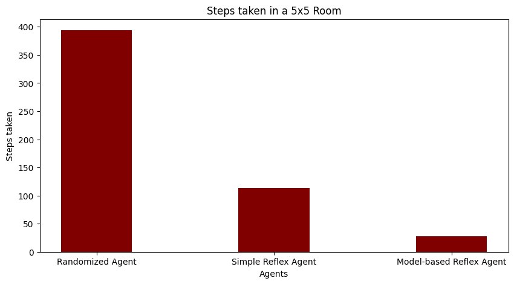

```python
import numpy as np
import matplotlib.pyplot as plt


# creating the dataset
data = {'Randomized Agent': 393.85, 'Simple Reflex Agent':113.85, 'Model-based Reflex Agent':27.29}
agents = list(data.keys())
values = list(data.values())

fig = plt.figure(figsize = (10, 5))

# creating the bar plot
plt.bar(agents, values, color ='maroon',
        width = 0.4)

plt.xlabel("Agents")
plt.ylabel("Steps taken")
plt.title("Steps taken in a 5x5 Room")
plt.show()
```

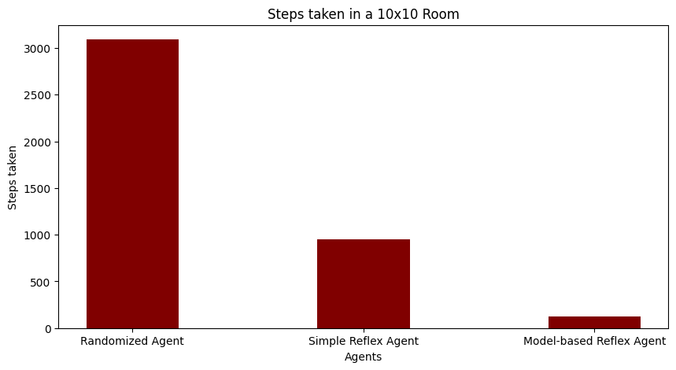

```python
# creating the dataset
data2 = {'Randomized Agent': 3091.87, 'Simple Reflex Agent':953.21, 'Model-based Reflex Agent':123.82}
agents = list(data2.keys())
values2 = list(data2.values())

fig = plt.figure(figsize = (10, 5))

# creating the bar plot
plt.bar(agents, values2, color ='maroon',
        width = 0.4)

plt.xlabel("Agents")
plt.ylabel("Steps taken")
plt.title("Steps taken in a 10x10 Room")
plt.show()
```

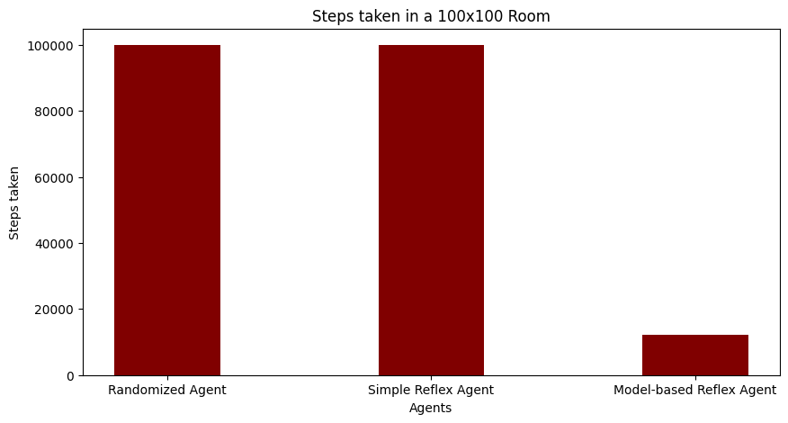

```python
# creating the dataset
data2 = {'Randomized Agent': 100000, 'Simple Reflex Agent':100000, 'Model-based Reflex Agent':12092.39}
agents = list(data2.keys())
values2 = list(data2.values())

fig = plt.figure(figsize = (10, 5))

# creating the bar plot
plt.bar(agents, values2, color ='maroon',
        width = 0.4)

plt.xlabel("Agents")
plt.ylabel("Steps taken")
plt.title("Steps taken in a 100x100 Room")
plt.show()
```

I set the max steps to 100000 as a hard limit for the agents. For both 5x5 and 10x10 rooms, all agents were able to finish within that limit, with the Model-based reflex agent performing the best. For the 100x100, the randmozied agent and simple reflex agent was not able to finish the room within 100000 steps, while the model-based reflex agent was the only agent able to.

From these graphs and charts, the model-based reflex agent is the best performing agent out of all three.

## Task 5: Robustness of the agent implementations [10 Points]

Describe how **your agent implementations** will perform

- if it is put into a rectangular room with unknown size,
- if the cleaning area can have an irregular shape (e.g., a hallway connecting two rooms), or
- if the room contains obstacles (i.e., squares that it cannot pass through and trigger the bumper sensors).
- if the dirt sensor is not perfect and gives 10% of the time a wrong reading (clean when it is dirty or dirty when it is clean).
- if the bumper sensor is not perfect and 10% of the time does not report a wall when there is one.

Answers

if it is put into a rectangular room with unknown size:

- The simple reflex agent will perform differently depending on the size of the unknown room. It will move until all squares are clean or it runs out of steps, which means that in large enough rooms, it will not have enough steps to clean the room.
- The randomized agent will perform poorly because it may continously revisit previously cleaned areas and lead to a long cleaning time, or may not fully clean at all.
- The model based agent will perform well because it will be able to remember where it has been, and because of it, it will clean the entire room at some point, though the time it takes to clean the room also depends on the size of the room.

if the cleaning area can have an irregular shape (e.g., a hallway connecting two rooms)

- The randomized agent will perform poorly as it can get stuck in one region or fail to go into narrow hallways properly
- The simple reflex agent may clean one room efficiently, but can fail to travel to the second room
- The model based reflex agent based on my implementation will perform the same way as my simple reflex agent, as it may be able to clean one room, but fail to travel to the other as it currently does only travels in a zig zag pattern which does not account for a second room or hallway.

If the room contains obstacles

if the dirt sensor is not perfect and gives 10% of the time a wrong reading (clean when it is dirty or dirty when it is clean).

- The randmozed agent doesn not rely on the dirt sensor to clean as it chooses to clean randomly, so it will not be affected much by the faulty sensor. The performance will still be worse compared to other agents
- The simple reflex agent relies on the dirt sensor to clean, so it is likely that it will miss a square when cleaning, so it may have to revisit areas in order to ensure cleanliness.
- The model based reflex agent based on my implementation will perform better if it is allowed to run multiple times within a room. Since the model based reflex agent will visit every square at least once, if it missed a square the first time due to a faulty sensor, by running it another time, it will be able to catch the dirty square.

if the bumper sensor is not perfect and 10% of the time does not report a wall when there is one.

- The randomized agent also does not rely on the bumper sensors to move, so it will not be affected much by the faulty sensor. The performance will still be the worst comapred to other agents
- The simple reflex agent may collide with walls more often due to the sensor inaccuracy, leading to worse performance because it will waste time moving into walls
- The model based reflex agent may collide with walls more often as well due to the sensor inaccuracy, but will perform better than the simple reflex agent because once the sensor does report accurately, it avoid hitting that wall again because it will have moved to the next row.

## Advanced task: Imperfect Dirt Sensor

- **Graduate students** need to complete this task [10 points]
- **Undergraduate students** can attempt this as a bonus task [max +5 bonus points].
1. Change your simulation environment to run experiments for the following problem: The dirt sensor has a 10% chance of giving the wrong reading. Perform experiments to observe how this changes the performance of the three implementations. Your model-based reflex agent is likely not able to clean the whole room, so you need to measure performance differently as a tradeoff between energy cost and number of uncleaned squares.
2. Design an implement a solution for your model-based agent that will clean better. Show the improvement with experiments.

```python
# Your code and discussion goes here
```

## More advanced implementation tasks

- **Obstacles:** Change your simulation environment to run experiments for the following problem: Add random obstacle squares that also trigger the bumper sensor. The agent does not know where the obstacles are. Perform experiments to observe how this changes the performance of the three implementations. Describe what would need to be done to perform better with obstacles. Add code if you can.
- **Agent for and environment with obstacles:** Implement an agent for an environment where the agent does not know how large the environment is (we assume it is rectangular), where it starts or where the obstacles are. An option would be to always move to the closest unchecked/uncleaned square (note that this is actually depth-first search).
- **Utility-based agent:** Change the environment for a $5 \times 5$ room, so each square has a fixed probability of getting dirty again. For the implementation, we give the environment a 2-dimensional array of probabilities. The utility of a state is defined as the number of currently clean squares in the room. Implement a utility-based agent that maximizes the expected utility over one full charge which lasts for 100000 time steps. To do this, the agent needs to learn the probabilities with which different squares get dirty again. This is very tricky!

```python
# Your ideas/code
```